# Fanfiction Analysis

Johannes Burgers

1/20/2022

## libraries

The following analysis makes use of the `tidyverse` suite of tools, along with help from `quanteda` and `qdap` for tokenization and cleaning.

## Corpus Overview

The *Legolas* corpus is a subset of an extremely large corpus. For the sake of text processing, all non-English texts have been removed from the *Legolas* corpus. That said, on occasion there may be non-English words interspersed within these texts.

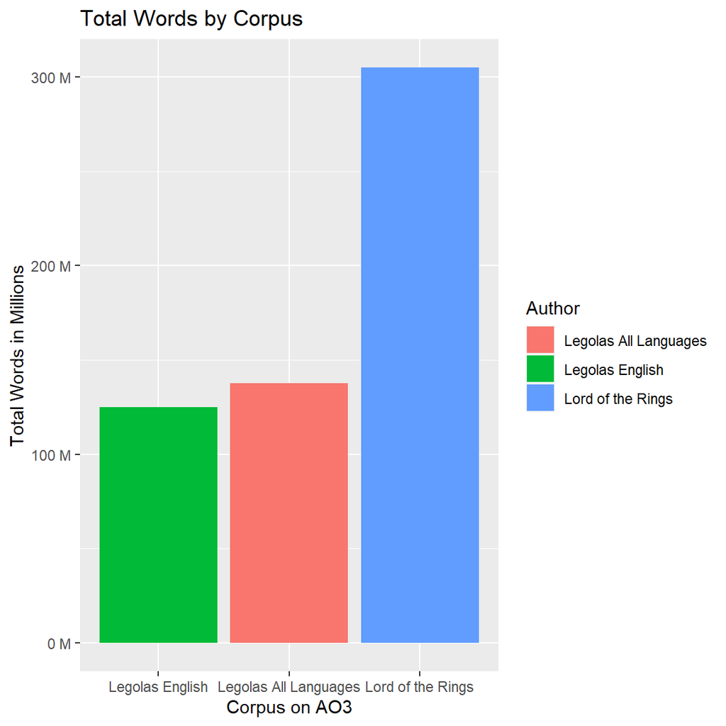

## Generate descriptive statistics

First, generate an overview of the syntactical and lexical complexity. This can be done with the help of the `quantdata` package [see here for reference](https://towardsdatascience.com/linguistic-complexity-measures-for-text-nlp-e4bf664bd660).

The following series of functions take the `fanfiction_df` and turn it into a corpus object using only the `ID` and `Content` as variables. The remainder of the `df` is left aside for later joining.

```r
#get list of English names
fanfiction_not_english <- fanfiction_names_df %>%
                      filter(Language != "English") %>%
                      select(ID)
```

```r
fanfiction_df_small <-  fanfiction_df %>%
                       distinct(ID, Content) %>%
                        anti_join(fanfiction_not_english)
```

Convert the `tibble` to a corpus object.

```r
# Creating a corpus
mycorpus <- corpus(fanfiction_df_small, docid_field = "ID", text_field = "Content")
```

Get basic descriptive statistics of text complexity. This information will need to be filtered out as some of the texts are clearly not accurately measured or have significant parts on in English.

```r
readability <- textstat_readability(mycorpus, c("meanSentenceLength","meanWordSyllables", "Flesch.Kincaid", "Flesch"), remove_hyphens = TRUE,
  min_sentence_length = 1, max_sentence_length = 10000,
  intermediate = FALSE) %>%
  mutate(document = as.integer(document))
```

Join readability scores with author and work details.

```r
## Join the tibbles back by author ID
readability_text <- fanfiction_df %>%
                    select(!(Content)) %>%
                    left_join(readability, by = c("ID" = "document")) %>%
                    left_join(fanfiction_names_df) %>%
                    filter(Language == "English")
```

- Possible analysis, do a correlation analysis of reading score and likes/kudos or comments.
- Advanced analysis, do PCA of the different variables.

## Tokenizing

Converting text elements to tokens.

```r
# Tokenisation
tok <- tokens(mycorpus, what = "word",
                   remove_punct = TRUE,
                   remove_symbols = TRUE,
                   remove_numbers = TRUE,
                   remove_url = TRUE,
                   remove_hyphens = FALSE,
                   verbose = TRUE,
                   include_docvars = TRUE)
tok <- tokens_tolower(tok)

tok <- tokens_select(tok, stopwords("english"), selection = "remove", padding = FALSE)
```

Measuring lexical diversity through tokens

```r
lexical_diversity <- dfm(tok) %>%
  textstat_lexdiv(measure = "TTR")
```

## TTR Table

```r
lexical_diversity <- lexical_diversity %>%
                      mutate(document = as.numeric(document))

lexical_diversity_table <- fanfiction_df %>%
                    select(!(Content)) %>%
                    left_join(lexical_diversity, by = c("ID" = "document")) %>%
                    left_join(fanfiction_names_df)
```

|  | Author | Title | TTR | Summary |
| --- | --- | --- | --- | --- |
| 1 | queefqueen | Love is a form of Madness | 0.600524148259079 | After BofA Tauriel hugs her delicate bump. For months there had been no news from the Love of Her Life. She is worried! Fixit, All Hawt! Dwarves live. This is my first venture into the wonderful world… |
| 2 | TaeAelin | My Home is Your Home | 0.587555886736215 | When Lindir pays Tauriel and Legolas a visit, he isn’t quite prepared for the sightseeing adventure the wood elves had in mind. |
| 3 | lynndyre | From Without, and from Within | 0.580350039777247 | Legolas and Thranduil part after the battle, and both must learn to see what they have been missing. |
| 4 | Tanis | The Guardian | 0.578144078144078 | It’s the Autumnal Equinox and magick is afoot throughout the ancient forest of Mirkwood. Thranduil sets out on a Mithrandir-prompted errand to find his small son a fearsome guardian. This is set in th… |
| 5 | suave_silver | Redemption | 0.572262272571232 | Solas seeks a way to return to Thedas. Legolas asks him if it’s what he really wants. |
| 6 | erobey | Gelera Abi | 0.57222093829443 | Written to accompany the MPA awards. This is the story that inspired Meril Thafn. |
| 7 | Cinderstrato | The White Light of Forever | 0.570684821786143 | Tauriel of the Greenwood fears no Vala. |
| 8 | Saentorine | Starlight Burnt Out | 0.567793074676679 | From hairline to neck, the burns distort her perfect skin with a raw red rash. The symmetry of her face is shattered by a gaping open wound, bare sinews binding cheek to jaw arrayed in petals like a s… |
| 9 | whizzy | The Woodland Express | 0.56716995741386 | Tauriel is the wrong age and the wrong size and in the wrong mood entirely to even consider riding in a google-eyed lime green caterpillar named Ralph. |
| 10 | erobey | Antala Kwinga (Bow Giving) | 0.567103109656301 | A story set in the Feud universe featuring young Legolas. Maltahondo appears as a loyal guardian as we share a glimpse into Legolas’ world at an important milestone in a young Wood Elf’s life. |
| Top 10 words based on Type-Token Ratio. Text’s closer to 1 are more lexically rich. |  |  |  |  |

## NGRAM

Ngrams had to be created in chunks to account for the heavy memory usage.

```r
ngram_df <- NULL
for (i in 1:nrow(fanfiction_df_small)) {
         temp <- NULL
         temp <-  fanfiction_df_small %>%
                   filter (row_number()==i) %>%
                     group_by(ID) %>%
                  unnest_tokens(bigram, Content, token = "ngrams", n = 2) %>%
                  separate(bigram, c("word1", "word2"), sep = " ") %>%
                  filter(!word1 %in% stop_words$word) %>%
                  filter(!word2 %in% stop_words$word) %>%
                  mutate(bigram = paste(word1,word2, sep = " ")) %>%
                  count(bigram, sort = TRUE) %>%
                  top_n(n, n = 100)


         ngram_df <- ngram_df %>%
                     bind_rows(temp)
          if (i%%250 == 0) {
      print(paste("Now processing text ",i," of", nrow(fanfiction_df_small), sep = ""))
            #added this to make sure R wasn't freezing.
    }
}
```

```
## [1] "Now processing text 250 of8717"
## [1] "Now processing text 500 of8717"
## [1] "Now processing text 750 of8717"
## [1] "Now processing text 1000 of8717"
## [1] "Now processing text 1250 of8717"
## [1] "Now processing text 1500 of8717"
## [1] "Now processing text 1750 of8717"
## [1] "Now processing text 2000 of8717"
## [1] "Now processing text 2250 of8717"
## [1] "Now processing text 2500 of8717"
## [1] "Now processing text 2750 of8717"
## [1] "Now processing text 3000 of8717"
## [1] "Now processing text 3250 of8717"
## [1] "Now processing text 3500 of8717"
## [1] "Now processing text 3750 of8717"
```

[output cut: 19 more lines]

```r
ngram_total <- ngram_df %>%
  group_by(bigram) %>%
    summarise(total_bigrams = sum(n))

ngram_top_thousand <- ngram_total %>%
                      ungroup() %>%
                      arrange(desc(total_bigrams)) %>%
                      top_n(n=1000)


ngram_top_ten_table <- ngram_top_thousand %>%
                      top_n(n=50) %>%
                addHtmlTableStyle(col.rgroup = c("none", "#F5FBFF"),
                    pos.caption = "bottom") %>%
  htmlTable(caption = "Top 50 ngrams")

ngram_top_ten_table
```

|  | bigram | total_bigrams |
| --- | --- | --- |
| 1 | chapter text | 37274 |
| 2 | middle earth | 17822 |
| 3 | lord elrond | 14172 |
| 4 | blue eyes | 10791 |
| 5 | deep breath | 9717 |
| 6 | minas tirith | 9329 |
| 7 | notes chapter | 9237 |
| 8 | king thranduil | 6437 |
| 9 | legolas looked | 5901 |
| 10 | eyes widened | 5359 |
| 11 | woodland realm | 4918 |
| 12 | lady galadriel | 4894 |
| 13 | wood elf | 4758 |
| 14 | legolas smiled | 4263 |
| 15 | legolas nodded | 4093 |
| 16 | thorin oakenshield | 3970 |
| 17 | prince legolas | 3784 |
| 18 | stepped forward | 3523 |
| 19 | elven king | 3442 |
| 20 | bilbo baggins | 3358 |
| 21 | uruk hai | 3296 |
| 22 | dol guldur | 3137 |
| 23 | lake town | 3041 |
| 24 | dark haired | 2925 |
| 25 | leaned forward | 2870 |
| 26 | thranduil looked | 2745 |
| 27 | master baggins | 2734 |
| 28 | dark lord | 2713 |
| 29 | elf lord | 2663 |
| 30 | text chapter | 2651 |
| 31 | legolas replied | 2551 |
| 32 | legolas eyes | 2536 |
| 33 | wood elves | 2525 |
| 34 | lonely mountain | 2495 |
| 35 | grey eyes | 2449 |
| 36 | eyes wide | 2394 |
| 37 | gil galad | 2362 |
| 38 | thranduil smiled | 2325 |
| 39 | thorin looked | 2307 |
| 40 | haired elf | 2303 |
| 41 | green eyes | 2223 |
| 42 | legolas sighed | 2205 |
| 43 | golden hair | 2202 |
| 44 | misty mountains | 2201 |
| 45 | elven prince | 2060 |
| 46 | eyes closed | 2044 |
| 47 | mellon nin | 2012 |
| 48 | dark hair | 1987 |
| 49 | lord celeborn | 1963 |
| 50 | swallowed hard | 1941 |
| Top 50 ngrams |  |  |

## Distinct words

Measuring distinct words in a corpus is complex. Heaps’ law indicates that the number of unique words is the inverse square of the total number of words. That is as texts get longer their unique words go down because there are only so many words in the English language. A better measure is

[figure not shown]

. The code below does this for the entire corpus, but fetches a lot of false positives, because what it sees as “unique” are actually scraping errors. It’s a good way to figure out what will need to be cleaned from the corpus.

```r
#Create a clean list of the count of each word in the corpus with contractions removed and possessives stripped, i.e. remove 's.

book_words_clean <- fanfiction_df_small %>%
unnest_tokens(word, Content)

book_words_clean_filtered <- book_words_clean %>%
                            filter(!str_detect(word,"['’.]"))

book_words_punctuation <- book_words_clean %>%
                            filter(str_detect(word,"['’`.]"))

book_words_punctuation <- book_words_punctuation %>%
                          mutate(word = qdap::replace_contraction(word, sent.cap = FALSE))

book_words_punctuation_extended <- book_words_punctuation %>%
                          mutate(word = str_remove_all(word,"['’.]")) %>%
                          mutate(word = str_remove_all(word, " s")) %>%
                          separate_rows(word, sep = " ")
```

```r
book_words_final <- book_words_clean_filtered %>%
                    bind_rows(book_words_punctuation_extended)
```

```r
book_words_final <- book_words_final %>%
                    count(ID, word, name = "nr_words", sort = TRUE)
```

Get the total number of words by work.

```r
total_words <- book_words_final %>%
  group_by(ID) %>%
  summarize(total = sum(nr_words))
```

Add the totals to the book_words tibble.

```r
book_words_total <- left_join(book_words_final, total_words)
```

Now calculate the tf_idf

```r
book_tf_idf <- book_words_total %>%
  bind_tf_idf(word, ID, nr_words)
```

### TF_IDF table

Thsi table needs to be joined back with the metadata to make some sense of it.

Get the top 3 distinct words for each book. This is still a lot of data to look through, but it might give an indication as to what is important about each work.

Join the metadata back to the distinct words table.

Distinct words of the corpus.

```r
distinct_words_total <- distinct_words %>%
  ungroup() %>%
  anti_join(stop_words) %>%
  group_by(word) %>%
  summarise(total_words = sum(nr_words)) %>%
  arrange(desc(total_words))


distinct_words_total_table <- distinct_words_total %>%
                              top_n(total_words, n= 50)

distinct_words_total_table %>%
  addHtmlTableStyle(col.rgroup = c("none", "#F5FBFF"),
                    pos.caption = "bottom") %>%
  htmlTable(header = c("Word", "Total Occurrences"),
            caption = "Top 50 unique words in the corpus by number or occurrences")
```

|  | Word | Total Occurrences |
| --- | --- | --- |
| 1 | thorin | 157523 |
| 2 | bilbo | 131525 |
| 3 | thranduil | 81457 |
| 4 | gimli | 69956 |
| 5 | bard | 69856 |
| 6 | aragorn | 63580 |
| 7 | kili | 54063 |
| 8 | kíli | 39595 |
| 9 | fili | 39515 |
| 10 | tauriel | 32377 |
| 11 | frodo | 32238 |
| 12 | elrohir | 30205 |
| 13 | fíli | 28425 |
| 14 | glorfindel | 27235 |
| 15 | haldir | 26282 |
| 16 | boromir | 24503 |
| 17 | faramir | 24205 |
| 18 | elrond | 22340 |
| 19 | erestor | 19123 |
| 20 | estel | 19083 |
| 21 | elladan | 16504 |
| 22 | sam | 14082 |
| 23 | thran | 11368 |
| 24 | merry | 10261 |
| 25 | pippin | 10248 |
| 26 | harry | 8014 |
| 27 | ori | 7704 |
| 28 | éomer | 7642 |
| 29 | sigrid | 7071 |
| 30 | dwalin | 6671 |
| 31 | eowyn | 6231 |
| 32 | nori | 6138 |
| 33 | gandalf | 5059 |
| 34 | melpomaen | 4841 |
| 35 | bards | 4773 |
| 36 | maglor | 4770 |
| 37 | frerin | 4753 |
| 38 | maedhros | 4734 |
| 39 | eomer | 4719 |
| 40 | loki | 4718 |
| 41 | mel | 4698 |
| 42 | éowyn | 4692 |
| 43 | gimlis | 4288 |
| 44 | bella | 4276 |
| 45 | kalin | 4224 |
| 46 | eldarion | 4203 |
| 47 | arwen | 4188 |
| 48 | legolass | 3987 |
| 49 | hobbit | 3919 |
| 50 | shakiiya | 3793 |
| Top 50 unique words in the corpus by number or occurrences |  |  |

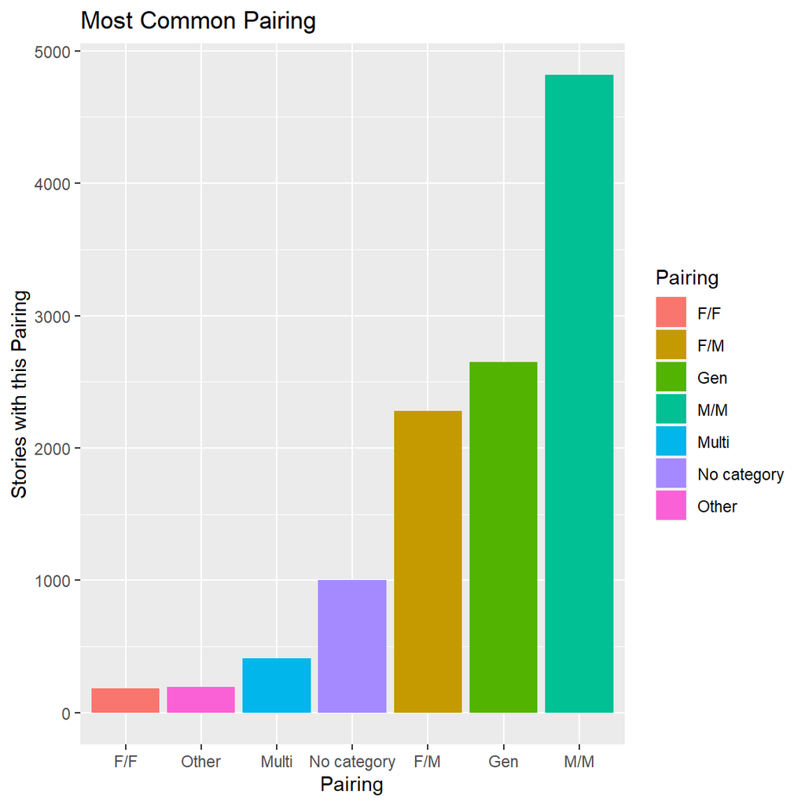

|  | Tags | n |
| --- | --- | --- |
| 1 | Legolas Greenleaf | 6036 |
| 2 | No Archive Warnings Apply | 5319 |
| 3 | Creator Chose Not To Use Archive Warnings | 3424 |
| 4 | Legolas | 2644 |
| 5 | Thranduil | 2129 |
| 6 | Gimli (Son of Glóin) | 1668 |
| 7 | Aragorn \| Estel | 1578 |
| 8 | Gimli | 1470 |
| 9 | Thranduil (Tolkien) | 1412 |
| 10 | Thorin Oakenshield | 1158 |
| 11 | Aragorn | 1093 |
| 12 | Angst | 1058 |
| 13 | Bilbo Baggins | 1011 |
| 14 | Fluff | 994 |
| 15 | Frodo Baggins | 870 |
| 16 | Kíli | 824 |
| 17 | Tauriel | 801 |
| 18 | Gimli (Son of Glóin)/Legolas Greenleaf | 780 |
| 19 | Pippin Took | 768 |
| 20 | Gandalf \| Mithrandir | 758 |
| 21 | Merry Brandybuck | 752 |
| 22 | Sam Gamgee | 704 |
| 23 | Fíli | 691 |
| 24 | Elrond | 683 |
| 25 | Gandalf | 682 |
| 26 | Elrond Peredhel | 675 |
| 27 | Graphic Depictions Of Violence | 672 |
| 28 | Humor | 661 |
| 29 | Friendship | 656 |
| 30 | Major Character Death | 625 |
| 31 | Aragorn \| Estel/Legolas Greenleaf | 596 |
| 32 | Hurt/Comfort | 594 |
| 33 | Romance | 592 |
| 34 | Bilbo Baggins/Thorin Oakenshield | 517 |
| 35 | Tauriel (Hobbit Movies) | 512 |
| 36 | Gimli/Legolas Greenleaf | 502 |
| 37 | Alternate Universe - Modern Setting | 456 |
| 38 | Arwen Undómiel | 440 |
| 39 | Boromir (Son of Denethor II) | 438 |
| 40 | Elrohir | 434 |
| 41 | Elladan | 428 |
| 42 | Arwen | 413 |
| 43 | Legolas Greenleaf & Thranduil | 411 |
| 44 | Thorin’s Company | 379 |
| 45 | Alternate Universe - Canon Divergence | 373 |
| 46 | Elrohir (Tolkien) | 370 |
| 47 | Dwalin | 368 |
| 48 | Legolas Greenleaf/Thranduil | 362 |
| 49 | Elladan (Tolkien) | 360 |
| 50 | Alternate Universe | 354 |

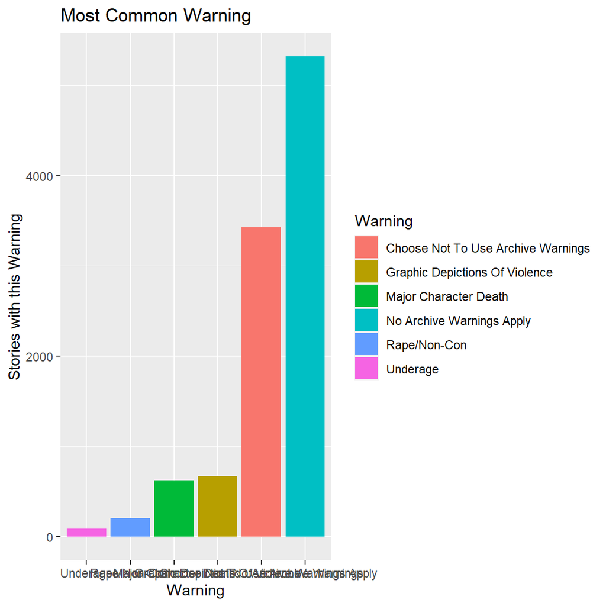